# Exploratory Data Analysis

Dutchak Bohdan

This is the EDA for my project. The idea is to classify the position of the player given parformance stats of his average game. I have collected this data from the [NBA Reference](https://www.basketball-reference.com/). This data contains ~10,000 individual players stats per game for seasons 2000-2020. It is collected by my data_parser.py script

```r
#install.packages("devtools")
#install.packages("psych")
#install.packages("dplyr")
#install.packages("ggcorrplot")
#install.packages("ggplot2")
#install.packages("plotly")
#install.packages("gridExtra")
#install.packages("ggpubr")
#install.packages("reshape2")
#install.packages("GGally")
#install.packages("broom")
```

```r
library(devtools)
library(psych)
library(dplyr)
library(ggcorrplot)
library(ggplot2)
library(plotly)
library(ggpubr)
library(reshape2)
library(GGally)
library(broom)
```

```r
data = read.csv('data/all_seasons.csv', head=T, sep=',')
head(data)
```

|  | Player | Pos | Ht | Wt | Exp | Age | G | GS | MP | FG | FGA | FG. | X3P | X3PA | X3P. | X2P | X2PA | X2P. | eFG. | FT | FTA | FT. | ORB | DRB | TRB | AST | STL | BLK | TOV | … |
| --- | --- | --- | --- | --- | --- | --- | --- | --- | --- | --- | --- | --- | --- | --- | --- | --- | --- | --- | --- | --- | --- | --- | --- | --- | --- | --- | --- | --- | --- | --- |
| 1 | Nick Anderson | SG | 198 | 93 | 10 | 32 | 72 | 72 | 29.1 | 4.3 | 10.9 | 0.391 | 1.8 | 5.5 | 0.332 | 2.4 | 5.3 | 0.452 | 0.476 | 0.5 | 1.1 | 0.487 | 1.2 | 3.6 | 4.7 | 1.7 | 1.3 | 0.2 | 1.3 | … |
| 2 | Jon Barry | SG | 193 | 88 | 7 | 30 | 62 | 1 | 20.7 | 2.6 | 5.6 | 0.465 | 1.1 | 2.5 | 0.429 | 1.5 | 3.1 | 0.495 | 0.561 | 1.7 | 1.9 | 0.922 | 0.6 | 2.0 | 2.6 | 2.4 | 1.2 | 0.1 | 1.4 | … |
| 3 | Tyrone Corbin | SF | 198 | 95 | 14 | 37 | 54 | 5 | 17.4 | 1.6 | 4.6 | 0.356 | 0.2 | 0.8 | 0.227 | 1.4 | 3.8 | 0.384 | 0.377 | 0.6 | 0.7 | 0.846 | 0.7 | 2.3 | 3.1 | 1.1 | 0.7 | 0.1 | 0.5 | … |
| 4 | Tony Delk | PG | 185 | 86 | 3 | 26 | 46 | 1 | 14.8 | 2.6 | 6.1 | 0.430 | 0.2 | 0.9 | 0.225 | 2.4 | 5.2 | 0.464 | 0.446 | 1.0 | 1.3 | 0.797 | 0.8 | 1.1 | 1.9 | 1.2 | 0.8 | 0.1 | 0.7 | … |
| 5 | Vlade Divac | C | 216 | 110 | 10 | 31 | 82 | 81 | 29.0 | 4.7 | 9.3 | 0.503 | 0.1 | 0.3 | 0.269 | 4.6 | 9.0 | 0.511 | 0.507 | 2.8 | 4.1 | 0.691 | 2.1 | 5.9 | 8.0 | 3.0 | 1.3 | 1.3 | 2.3 | … |
| 6 | Lawrence Funderburke | PF | 206 | 104 | 2 | 29 | 75 | 1 | 13.7 | 2.5 | 4.7 | 0.523 | 0.0 | 0.0 | 0.000 | 2.5 | 4.7 | 0.526 | 0.523 | 1.5 | 2.2 | 0.706 | 1.3 | 1.8 | 3.1 | 0.4 | 0.4 | 0.3 | 0.5 | … |

## Data Exploration

Let’s get familiar with the data.

### Features description

```r
names(data)
```

```
##  [1] "Player" "Pos"    "Ht"     "Wt"     "Exp"    "Age"    "G"      "GS"
##  [9] "MP"     "FG"     "FGA"    "FG."    "X3P"    "X3PA"   "X3P."   "X2P"
## [17] "X2PA"   "X2P."   "eFG."   "FT"     "FTA"    "FT."    "ORB"    "DRB"
## [25] "TRB"    "AST"    "STL"    "BLK"    "TOV"    "PF"     "PTS.G"  "Season"
```

| Name | Data type | Feature type | Measurement | Description |
| --- | --- | --- | --- | --- |
| Player | string | categorical | none | Full player’ name |
| **Pos** | string | categorical (**target**) | 5 unique classes | Players position in a team: Center, Power Forward, Small Forward, Shooting Guard, Point Guard |
| Ht | float | numerical | cm | Players height |
| Wt | float | numerical | kg | Players weight |
| Exp | int | numerical | years | Years in the NBA |
| Age | int | numerical | full years | Players age |
| G | int | numerical | none | Games played in the season |
| GS | int | numerical | none | Games started |
| MP | float | numerical | minutes | Minutes played per game |
| FG | float | numerical | field goals | Field goals per game |
| FGA | float | numerical | attemps | Field goal attempts per game |
| FG% | float | numerical | percentage | % of successful fied goals in the season |
| 3P | float | numerical | shots | 3-pointers per game |
| 3PA | float | numerical | attemps | 3-point goal attempts per game |
| 3P% | float | numerical | percentage | % of successful 3-point goals in the season |
| 2P | float | numerical | shots | 2-pointers per game |
| 2PA | float | numerical | attemps | 2-point goal attempts per game |
| 2P% | float | numerical | percentage | % of successful 2-point goals in the season |
| eFG% | float | numerical | percentage | Effective Field Goal Percentage |
| FT | float | numerical | shots | Free throws per game |
| FTA | float | numerical | attemps | Free throws attempts per game |
| FT% | float | numerical | percentage | % of successful Free throws in the season |
| ORB | float | numerical | rebounds | Offensive Rebounds Per Game |
| DRB | float | numerical | rebounds | Deffensive Rebounds Per Game |
| TRB | float | numerical | rebounds | Total Rebounds Per Game |
| AST | float | numerical | assists | Assists per game |
| STL | float | numerical | steals | Steals per game |
| BLK | float | numerical | blocks | blocks per game |
| TOV | float | numerical | blocks | Turnovers per game |
| PF | float | numerical | fouls | Personal fouls per game |
| PTS/G | float | numerical | points | Points per game |
| Season | int | categorical | year | season |

### Missing Data

First of all, let’s see whether we have any missing values. If so, what should we do with them

```r
options(warn=-1)
colSums(is.na(data))
```

```
## Player    Pos     Ht     Wt    Exp    Age      G     GS     MP     FG    FGA
##      0      0      0      0      0      0      0      0      0      0      0
##    FG.    X3P   X3PA   X3P.    X2P   X2PA   X2P.   eFG.     FT    FTA    FT.
##     65      0      0   1743      0      0    113     65      0      0    557
##    ORB    DRB    TRB    AST    STL    BLK    TOV     PF  PTS.G Season
##      0      0      0      0      0      0      0      0      0      0
```

```r
X2Pna <- data[is.na(data$X2P.),]
head(X2Pna[16:18])
```

|  | X2P | X2PA | X2P. |
| --- | --- | --- | --- |
| 36 | 0 | 0 | NA |
| 216 | 0 | 0 | NA |
| 416 | 0 | 0 | NA |
| 605 | 0 | 0 | NA |
| 705 | 0 | 0 | NA |
| 772 | 0 | 0 | NA |

```r
X3Pna <- data[is.na(data$X3P.),]
head(X3Pna[13:15])
```

|  | X3P | X3PA | X3P. |
| --- | --- | --- | --- |
| 8 | 0 | 0 | NA |
| 12 | 0 | 0 | NA |
| 14 | 0 | 0 | NA |
| 24 | 0 | 0 | NA |
| 25 | 0 | 0 | NA |
| 26 | 0 | 0 | NA |

Missing values analysis shows, that NA type is only in the rows, where player took 0 attempts of some sort of shot. Since the table could not divide by zero to get his % of shots, we don’t have any value there, so we can fill it manually with 0’s.

```r
data[is.na(data)] <- 0
```

### Univariate Analysis

When exploring our dataset and its features, we have many options available to us. We can explore each feature individually, or compare pairs of features, finding the correlation between. Let’s start with some simple Univariate (one feature) analysis.

```r
describe(data)
```

|  | vars | n | mean | sd | median | trimmed | mad | min | max | range | skew | kurtosis | se |
| --- | --- | --- | --- | --- | --- | --- | --- | --- | --- | --- | --- | --- | --- |
| Player* | 1 | 11071 | 1011.0335110 | 586.6800760 | 1011.000 | 1011.1261149 | 759.0912000 | 1 | 2033.0 | 2032.0 | -0.009391879 | -1.205575116 | 5.575809329 |
| Pos* | 2 | 11071 | 2.9808509 | 1.4222373 | 3.000 | 2.9760641 | 1.4826000 | 1 | 5.0 | 4.0 | 0.037502475 | -1.309353147 | 0.013516948 |
| Ht | 3 | 11071 | 200.3395357 | 9.1927699 | 201.000 | 200.7694479 | 10.3782000 | 160 | 231.0 | 71.0 | -0.385995492 | -0.234614133 | 0.087368114 |
| Wt | 4 | 11071 | 99.8982928 | 12.4288816 | 100.000 | 99.6409620 | 13.3434000 | 61 | 163.0 | 102.0 | 0.220645199 | 0.007187131 | 0.118124131 |
| Exp | 5 | 11071 | 4.6453798 | 4.0736863 | 4.000 | 4.1928418 | 4.4478000 | 0 | 21.0 | 21.0 | 0.820872084 | -0.049664583 | 0.038716327 |
| Age | 6 | 11071 | 26.6915364 | 4.2937277 | 26.000 | 26.4176358 | 4.4478000 | 18 | 44.0 | 26.0 | 0.550454195 | -0.263112658 | 0.040807602 |
| G | 7 | 11071 | 46.9135579 | 26.5961505 | 51.000 | 47.9841933 | 35.5824000 | 1 | 82.0 | 81.0 | -0.248375320 | -1.349240271 | 0.252769899 |
| GS | 8 | 11071 | 22.7739138 | 28.0286360 | 8.000 | 18.5898160 | 11.8608000 | 0 | 82.0 | 82.0 | 0.974227350 | -0.583562744 | 0.266384247 |
| MP | 9 | 11071 | 19.9033963 | 10.0387861 | 19.200 | 19.7277295 | 12.1573200 | 0 | 43.7 | 43.7 | 0.139071604 | -1.022399463 | 0.095408655 |
| FG | 10 | 11071 | 2.9749887 | 2.1556473 | 2.500 | 2.7298182 | 2.0756400 | 0 | 12.2 | 12.2 | 0.969631931 | 0.493810115 | 0.020487279 |

[output cut: 22 more lines]

The dataset has 11071 observations and 32 features, 3 of them are categorical: Player, Pos and Season, all the other are numerical. Among the 11071 observations, only 2033 are unique. It means that the data is only about 2033 unique players and their performance in different seasons. I decided to collect seasons separately, since a player could change his position between the seasons.

We also need to know how good the data is balanced and what is it’s distributions in order to make further decisions. The bar plot shows the distribution of classes in the target variable.

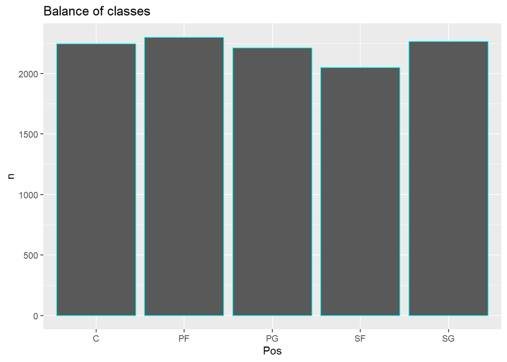

```r
g <- data %>% count(Pos)
ggplot(g, aes(x=Pos, y=n)) + geom_bar(stat='identity', col="cyan") + ggtitle("Balance of classes")
```

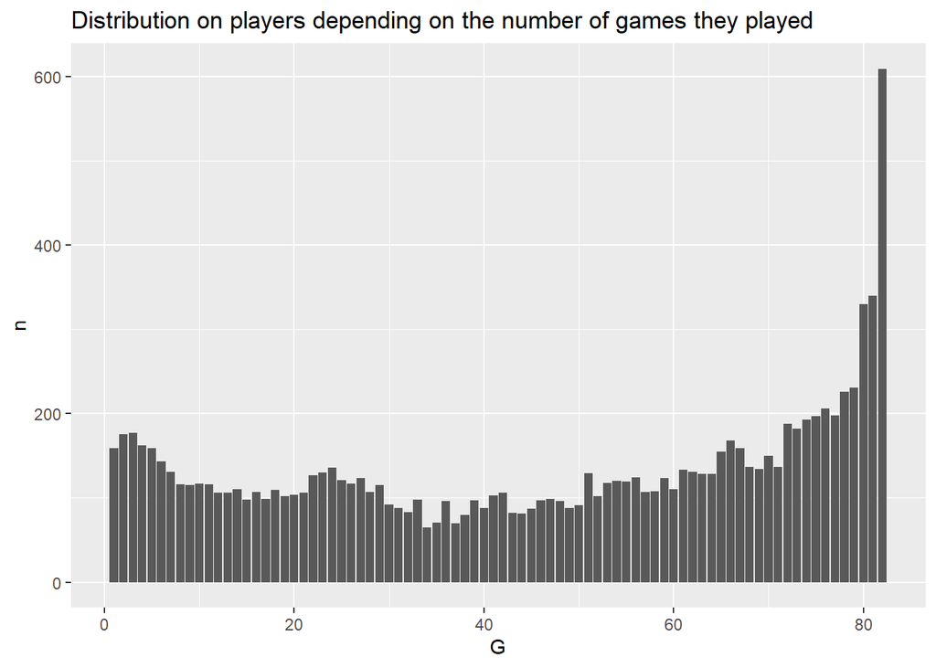

```r
g <- data %>% count(G)
ggplot(g, aes(x=G, y=n)) + geom_bar(stat='identity') + ggtitle("Distribution on players depending on the number of games they played")
```

To decide what to do with “unrepresentative” observations, i.e., where the player participated only in a relatively small number of games, look at the histogram. Fortunately, there is a similar amount of such players and players who played the “middle” number of games. The bigger this number, the more accurate stats are. So I decided to keep such observations.

```r
options(warn=-1)
t(aggregate(data, list(data$Pos), FUN=mean))[3:33,]
```

```
##        [,1]         [,2]         [,3]         [,4]         [,5]
## Pos    NA           NA           NA           NA           NA
## Ht     "210.8179"   "205.9835"   "187.5613"   "201.7632"   "195.4064"
## Wt     "113.84506"  "107.55043"  " 85.11126"  " 99.72314"  " 92.89409"
## Exp    "4.977738"   "4.805217"   "4.609227"   "4.532227"   "4.291262"
## Age    "26.99288"   "26.66696"   "26.85844"   "26.52344"   "26.40688"
## G      "46.66919"   "46.56826"   "46.45455"   "47.77734"   "47.17343"
## GS     "23.47240"   "21.54826"   "22.71551"   "24.26367"   "22.03619"
## MP     "17.70098"   "19.19548"   "20.78204"   "21.05820"   "20.90388"
## FG     "2.614782"   "2.959087"   "3.029444"   "3.085449"   "3.195190"
## FGA    "5.231879"   "6.403087"   "7.206649"   "7.081787"   "7.536981"
## FG.    "0.4818954"  "0.4446257"  "0.4023541"  "0.4183472"  "0.4053023"
## X3P    "0.09532502" "0.38573913" "0.76024423" "0.74458008" "0.91575463"
## X3PA   "0.2958148"  "1.1324783"  "2.2047942"  "2.1244141"  "2.5767432"
## X3P.   "0.09160508" "0.19292783" "0.30425373" "0.29784619" "0.31512048"
## X2P    "2.517809"   "2.573826"   "2.270149"   "2.341797"   "2.279921"
## X2PA   "4.934817"   "5.271130"   "5.003030"   "4.957373"   "4.961827"
## X2P.   "0.4912863"  "0.4699652"  "0.4326119"  "0.4552144"  "0.4407648"
## eFG.   "0.4887809"  "0.4721378"  "0.4528955"  "0.4710903"  "0.4655684"
## FT     "1.299466"   "1.395783"   "1.489959"   "1.463770"   "1.522374"
## FTA    "1.931790"   "1.934522"   "1.870782"   "1.912402"   "1.920521"
## FT.    "0.6253166"  "0.6594017"  "0.7349833"  "0.6973638"  "0.7298416"
## ORB    "1.5690116"  "1.3094783"  "0.4106287"  "0.7888672"  "0.5034422"
## DRB    "3.308816"   "3.190478"   "1.784487"   "2.526367"   "1.962798"
## TRB    "4.875913"   "4.497826"   "2.192944"   "3.313232"   "2.463283"
## AST    "0.8673642"  "1.1150000"  "3.5502035"  "1.4600098"  "1.8669462"
## STL    "0.4313001"  "0.5336522"  "0.7901854"  "0.6837402"  "0.6961606"
## BLK    "0.8002671"  "0.5035217"  "0.1374943"  "0.3277832"  "0.2080318"
## TOV    "1.008014"   "1.032478"   "1.484848"   "1.072021"   "1.145808"
## PF     "2.129029"   "1.948652"   "1.610493"   "1.732715"   "1.596778"
## PTS.G  "6.622039"   "7.696652"   "8.302668"   "8.377979"   "8.825905"
## Season "2010.152"   "2010.389"   "2010.249"   "2010.345"   "2010.959"
```

Taking a glance at the average values of each feature distributed by columns, we can notice some values age siglificantly different, but let’s look at it in more representative way plotting it.

### Bi-variate Analysis

So far, we have analised all features individually. Let’s now start combining some of these features together to obtain further insight into the interactions between them.

```r
data_by_pos <- aggregate(data, list(data$Pos), mean)
attach(mtcars)
```

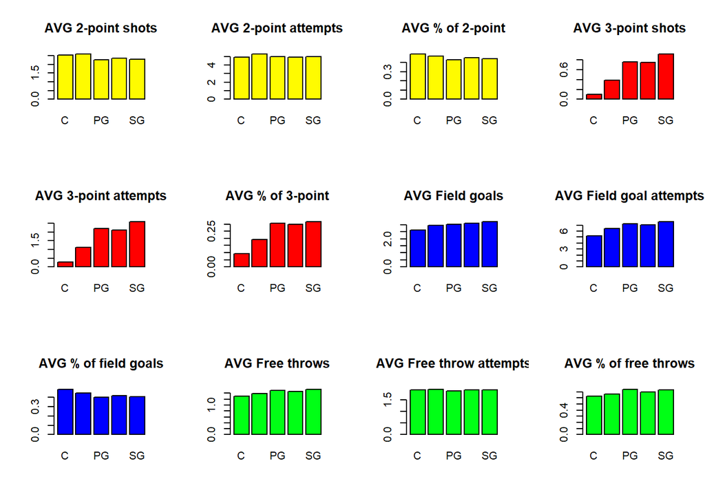

```r
par(mfrow=c(3,4))
barplot(data_by_pos$X2P, main="AVG 2-point shots", names.arg = c('C', 'PF', 'PG', 'SF', 'SG'), col="#fffb00")
barplot(data_by_pos$X2PA, main="AVG 2-point attempts", names.arg = c('C', 'PF', 'PG', 'SF', 'SG'), col="#fffb00")
barplot(data_by_pos$X2P., main="AVG % of 2-point", names.arg = c('C', 'PF', 'PG', 'SF', 'SG'), col="#fffb00")
barplot(data_by_pos$X3P, main="AVG 3-point shots", names.arg = c('C', 'PF', 'PG', 'SF', 'SG'), col="red")
barplot(data_by_pos$X3PA, main="AVG 3-point attempts", names.arg = c('C', 'PF', 'PG', 'SF', 'SG'), col="red")
barplot(data_by_pos$X3P., main="AVG % of 3-point", names.arg = c('C', 'PF', 'PG', 'SF', 'SG'), col="red")

barplot(data_by_pos$FG, main="AVG Field goals", names.arg = c('C', 'PF', 'PG', 'SF', 'SG'), col="blue")
barplot(data_by_pos$FGA, main="AVG Field goal attempts", names.arg = c('C', 'PF', 'PG', 'SF', 'SG'), col="blue")
barplot(data_by_pos$FG., main="AVG % of field goals", names.arg = c('C', 'PF', 'PG', 'SF', 'SG'), col="blue")
barplot(data_by_pos$FT, main="AVG Free throws", names.arg = c('C', 'PF', 'PG', 'SF', 'SG'), col="#00ff15")
barplot(data_by_pos$FTA, main="AVG Free throw attempts", names.arg = c('C', 'PF', 'PG', 'SF', 'SG'), col="#00ff15")
barplot(data_by_pos$FT., main="AVG % of free throws", names.arg = c('C', 'PF', 'PG', 'SF', 'SG'), col="#00ff15")
```

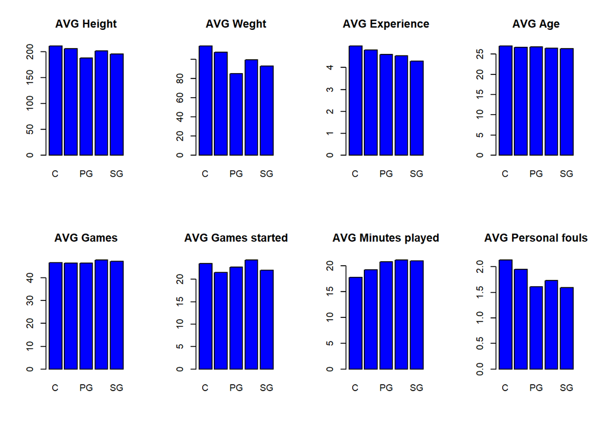

```r
attach(mtcars)
par(mfrow=c(2,4))

barplot(data_by_pos$Ht, main="AVG Height", names.arg = c('C', 'PF', 'PG', 'SF', 'SG'), col="blue")
barplot(data_by_pos$Wt, main="AVG Weght", names.arg = c('C', 'PF', 'PG', 'SF', 'SG'), col="blue")
barplot(data_by_pos$Exp, main="AVG Experience", names.arg = c('C', 'PF', 'PG', 'SF', 'SG'), col="blue")
barplot(data_by_pos$Age, main="AVG Age", names.arg = c('C', 'PF', 'PG', 'SF', 'SG'), col="blue")
barplot(data_by_pos$G, main="AVG Games", names.arg = c('C', 'PF', 'PG', 'SF', 'SG'), col="blue")
barplot(data_by_pos$GS, main="AVG Games started", names.arg = c('C', 'PF', 'PG', 'SF', 'SG'), col="blue")
barplot(data_by_pos$MP, main="AVG Minutes played", names.arg = c('C', 'PF', 'PG', 'SF', 'SG'), col="blue")
barplot(data_by_pos$PF, main="AVG Personal fouls", names.arg = c('C', 'PF', 'PG', 'SF', 'SG'), col="blue")
```

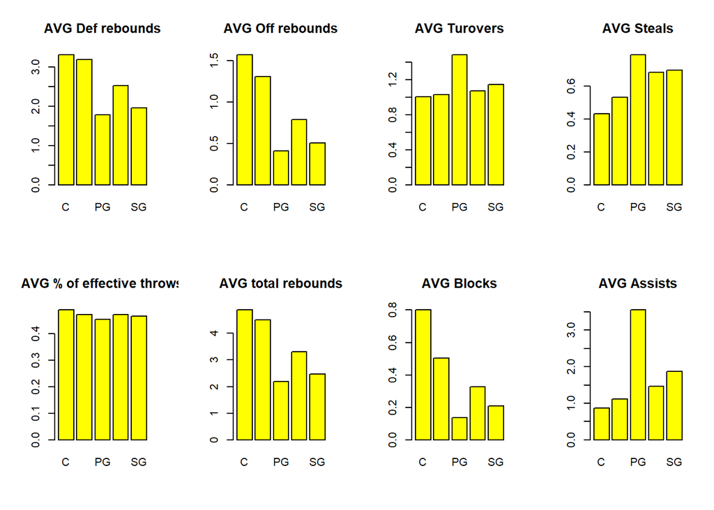

```r
attach(mtcars)
par(mfrow=c(2,4))
barplot(data_by_pos$DRB, main="AVG Def rebounds", names.arg = c('C', 'PF', 'PG', 'SF', 'SG'), col="yellow")
barplot(data_by_pos$ORB, main="AVG Off rebounds", names.arg = c('C', 'PF', 'PG', 'SF', 'SG'), col="yellow")
barplot(data_by_pos$TOV, main="AVG Turovers", names.arg = c('C', 'PF', 'PG', 'SF', 'SG'), col="yellow")
barplot(data_by_pos$STL, main="AVG Steals", names.arg = c('C', 'PF', 'PG', 'SF', 'SG'), col="yellow")
barplot(data_by_pos$eFG., main="AVG % of effective throws", names.arg = c('C', 'PF', 'PG', 'SF', 'SG'), col="yellow")
barplot(data_by_pos$TRB, main="AVG total rebounds", names.arg = c('C', 'PF', 'PG', 'SF', 'SG'), col="yellow")
barplot(data_by_pos$BLK, main="AVG Blocks", names.arg = c('C', 'PF', 'PG', 'SF', 'SG'), col="yellow")
barplot(data_by_pos$AST, main="AVG Assists", names.arg = c('C', 'PF', 'PG', 'SF', 'SG'), col="yellow")
```

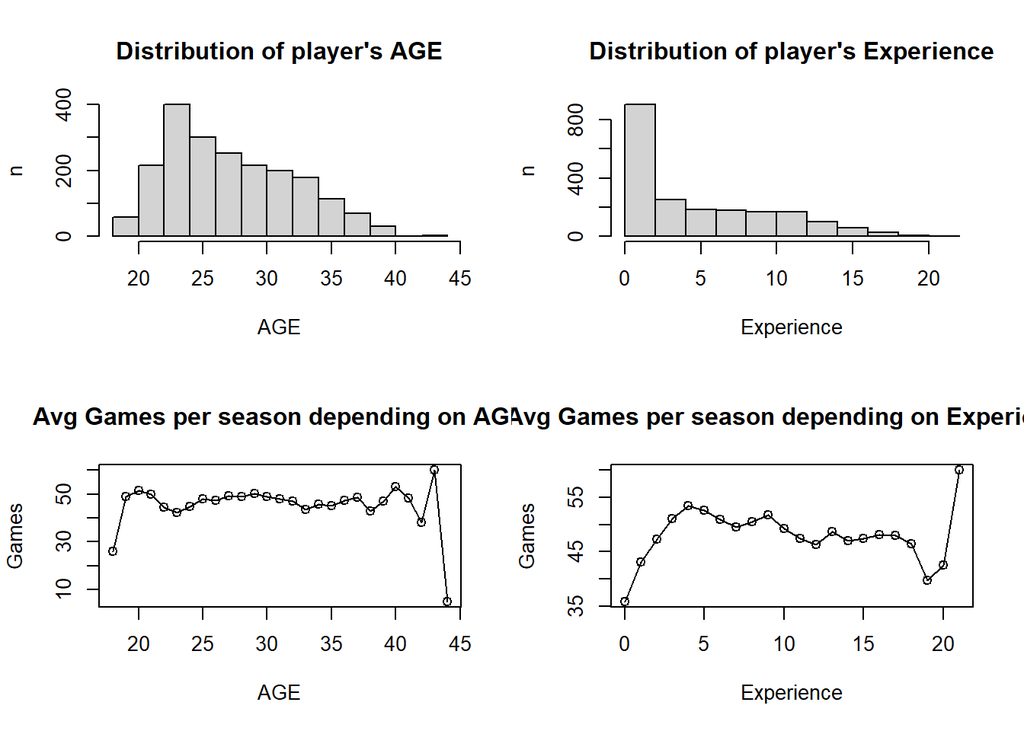

```r
attach(mtcars)

par(mfrow=c(2,2))

hist(aggregate(data, list(data$Player), max)$Age, main="Distribution of player's AGE", xlab="AGE", ylab="n")
hist(aggregate(data, list(data$Player), max)$Exp, main="Distribution of player's Experience", xlab="Experience", ylab="n")
plot(aggregate(data, list(data$Age), mean)$Age, aggregate(data, list(data$Age), mean)$G, type='o', main="Avg Games per season depending on AGE", xlab="AGE", ylab="Games")
plot(aggregate(data, list(data$Exp), mean)$Exp, aggregate(data, list(data$Exp), mean)$G, type='o', main="Avg Games per season depending on Experience", xlab="Experience", ylab="Games")
```

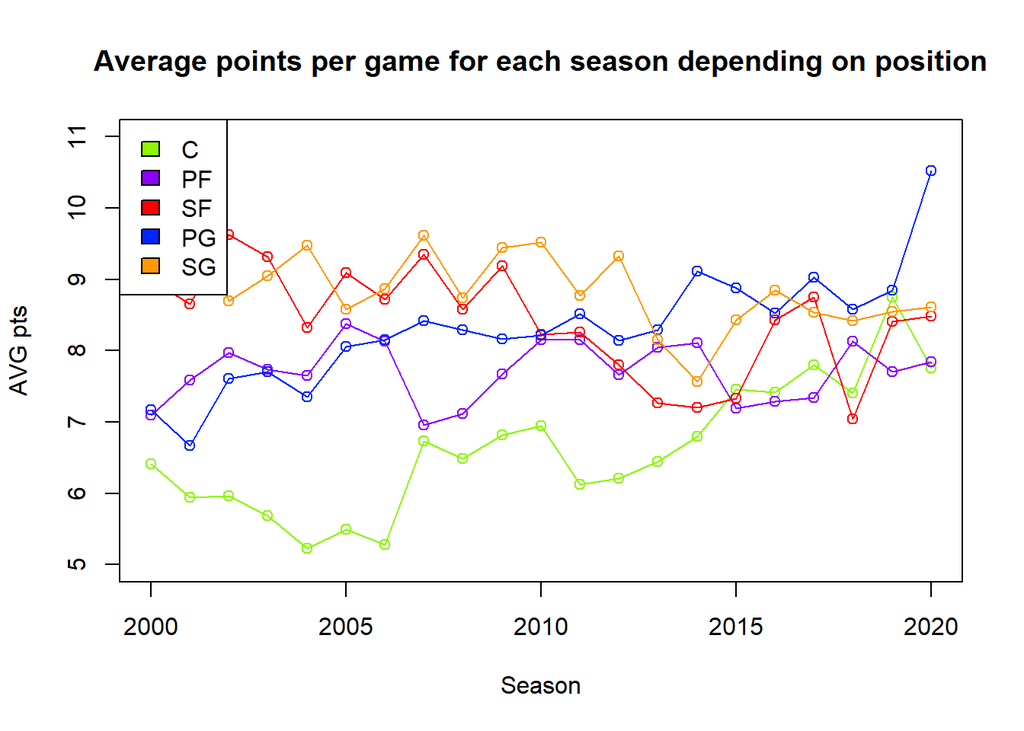

```r
c = data[data$Pos == 'C', ]
c = aggregate(c, list(c$Season), mean)$PTS.G
pf = data[data$Pos == 'PF', ]
pf = aggregate(pf, list(pf$Season), mean)$PTS.G
sf = data[data$Pos == 'SF', ]
sf = aggregate(sf, list(sf$Season), mean)$PTS.G
sg = data[data$Pos == 'SG', ]
sg = aggregate(sg, list(sg$Season), mean)$PTS.G
pg = data[data$Pos == 'PG', ]
pg = aggregate(pg, list(pg$Season), mean)$PTS.G

plot(unique(data$Season), c, type='o', col='#8df801', ylim=c(5,11), ylab='AVG pts', xlab='Season', main="Average points per game for each season depending on position")
lines(unique(data$Season), pf, type='o', col='#8c00ff')
lines(unique(data$Season), sf, type='o', col='#ff0000')
lines(unique(data$Season), pg, type='o', col='#0026ff')
lines(unique(data$Season), sg, type='o', col='#ff9900')
legend(x='topleft',legend=c('C','PF','SF','PG','SG'),fill=c('#8df801','#8c00ff','#ff0000','#0026ff','#ff9900'))
```

### Handling Outliers

Every dataset ought to have outliers, or observations that can decrease the accuracy. Previous analysis shows, that this dataset is pretty “clean”, but still it contains many observations that are beyond 1st or 3rd quartile + 1.5 IQR, that we can see on the boxplots below. I consider this cases as players, who are uprising stars or just had successful season. Besides, each feature has such outliers, so I decided to keep them.

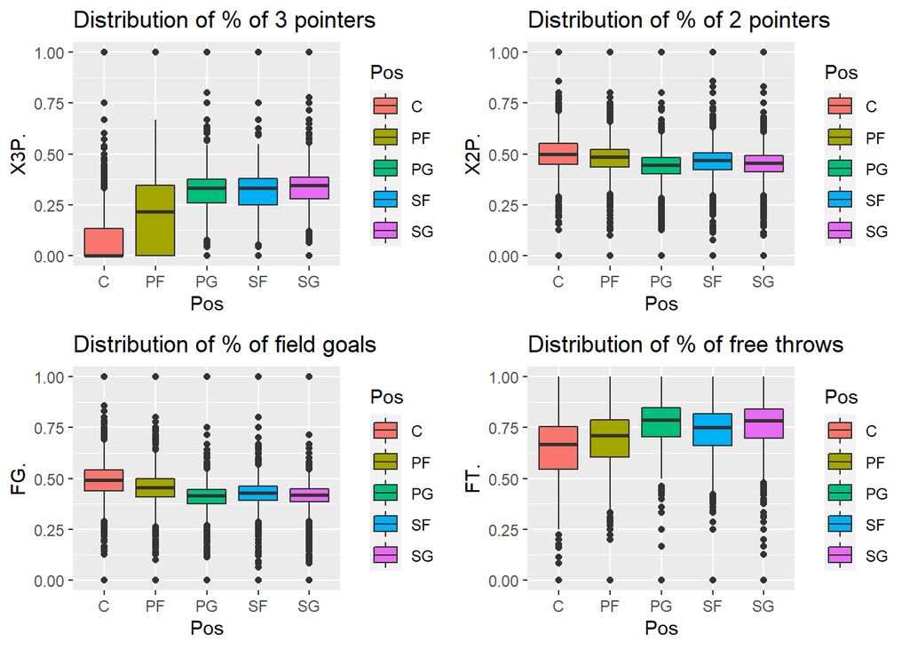

```r
x3p <- ggplot(data=data, aes(x=Pos, y=X3P.)) + geom_boxplot(aes(fill=Pos)) + ggtitle("Distribution of % of 3 pointers")
x2p <- ggplot(data=data, aes(x=Pos, y=X2P.)) + geom_boxplot(aes(fill=Pos)) + ggtitle("Distribution of % of 2 pointers")
fg <- ggplot(data=data, aes(x=Pos, y=FG.)) + geom_boxplot(aes(fill=Pos)) + ggtitle("Distribution of % of field goals")
ft <- ggplot(data=data, aes(x=Pos, y=FT.)) + geom_boxplot(aes(fill=Pos)) + ggtitle("Distribution of % of free throws")
ggarrange(x3p, x2p, fg, ft, ncol=2, nrow=2)
```

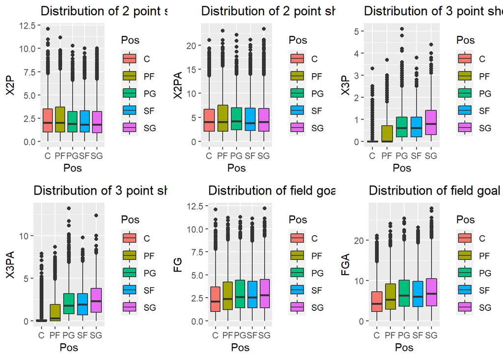

```r
ggarrange(ggplot(data=data, aes(x=Pos, y=X2P)) + geom_boxplot(aes(fill=Pos)) + ggtitle("Distribution of 2 point shots"),
    ggplot(data=data, aes(x=Pos, y=X2PA)) + geom_boxplot(aes(fill=Pos)) + ggtitle("Distribution of 2 point shot attempts"),
    ggplot(data=data, aes(x=Pos, y=X3P)) + geom_boxplot(aes(fill=Pos)) + ggtitle("Distribution of 3 point shots"),
    ggplot(data=data, aes(x=Pos, y=X3PA)) + geom_boxplot(aes(fill=Pos)) + ggtitle("Distribution of 3 point shot attempts"),
    ggplot(data=data, aes(x=Pos, y=FG)) + geom_boxplot(aes(fill=Pos)) + ggtitle("Distribution of field goals"),
    ggplot(data=data, aes(x=Pos, y=FGA)) + geom_boxplot(aes(fill=Pos)) + ggtitle("Distribution of field goal attempts"),
    ncol=3, nrow=2)
```

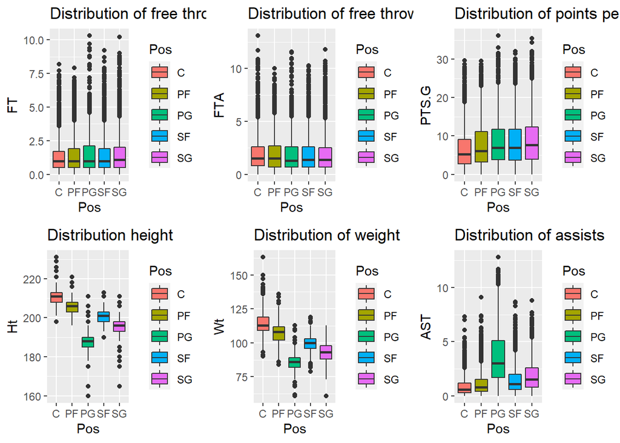

```r
ggarrange(ggplot(data=data, aes(x=Pos, y=FT)) + geom_boxplot(aes(fill=Pos)) + ggtitle("Distribution of free throws"),
    ggplot(data=data, aes(x=Pos, y=FTA)) + geom_boxplot(aes(fill=Pos)) + ggtitle("Distribution of free throw attempts"),
    ggplot(data=data, aes(x=Pos, y=PTS.G)) + geom_boxplot(aes(fill=Pos)) + ggtitle("Distribution of points per game"),
    ggplot(data=data, aes(x=Pos, y=Ht)) + geom_boxplot(aes(fill=Pos)) + ggtitle("Distribution height"),
    ggplot(data=data, aes(x=Pos, y=Wt)) + geom_boxplot(aes(fill=Pos)) + ggtitle("Distribution of weight"),
    ggplot(data=data, aes(x=Pos, y=AST)) + geom_boxplot(aes(fill=Pos)) + ggtitle("Distribution of assists"),
    ncol=3, nrow=2)
```

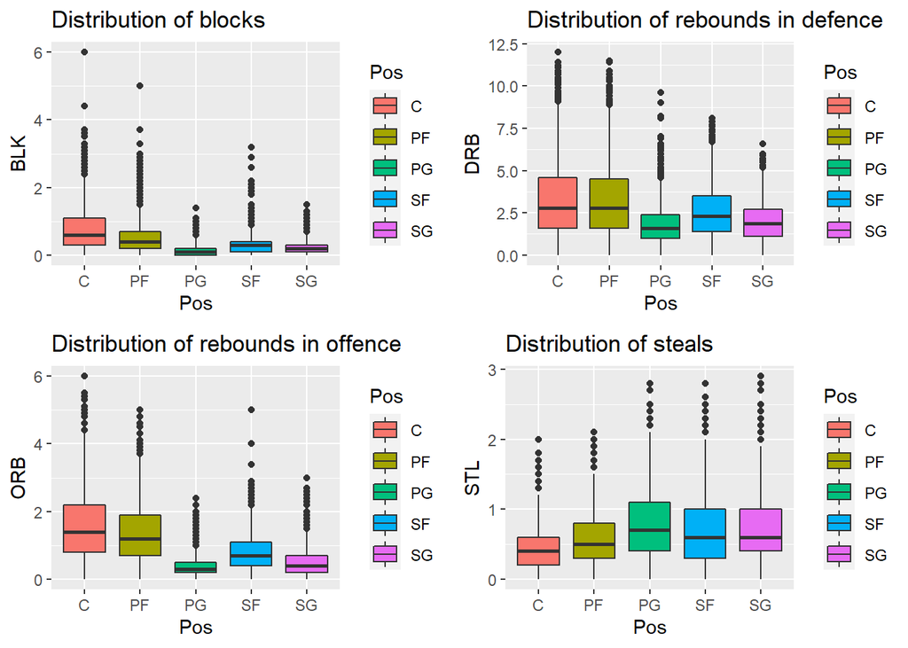

```r
ggarrange(ggplot(data=data, aes(x=Pos, y=BLK)) + geom_boxplot(aes(fill=Pos)) + ggtitle("Distribution of blocks"),
    ggplot(data=data, aes(x=Pos, y=DRB)) + geom_boxplot(aes(fill=Pos)) + ggtitle("Distribution of rebounds in defence"),
    ggplot(data=data, aes(x=Pos, y=ORB)) + geom_boxplot(aes(fill=Pos)) + ggtitle("Distribution of rebounds in offence"),
    ggplot(data=data, aes(x=Pos, y=STL)) + geom_boxplot(aes(fill=Pos)) + ggtitle("Distribution of steals"),
    ncol=2, nrow=2)
```

### Feature Encoding

Remember that Machine Learning algorithms perform Linear Algebra on Matrices, which means all features need have numeric values. The process of converting Categorical Features into values is called Encoding. Let’s encode all positions to the corresponding numbers.

```r
data$Pos <- replace(data$Pos, data$Pos == 'C', 5)
data$Pos <- replace(data$Pos, data$Pos == 'PF', 4)
data$Pos <- replace(data$Pos, data$Pos == 'SF', 3)
data$Pos <- replace(data$Pos, data$Pos == 'SG', 2)
data$Pos <- replace(data$Pos, data$Pos == 'PG', 1)
head(data)
```

|  | Player | Pos | Ht | Wt | Exp | Age | G | GS | MP | FG | FGA | FG. | X3P | X3PA | X3P. | X2P | X2PA | X2P. | eFG. | FT | FTA | FT. | ORB | DRB | TRB | AST | STL | BLK | TOV | … |
| --- | --- | --- | --- | --- | --- | --- | --- | --- | --- | --- | --- | --- | --- | --- | --- | --- | --- | --- | --- | --- | --- | --- | --- | --- | --- | --- | --- | --- | --- | --- |
| 1 | Nick Anderson | 2 | 198 | 93 | 10 | 32 | 72 | 72 | 29.1 | 4.3 | 10.9 | 0.391 | 1.8 | 5.5 | 0.332 | 2.4 | 5.3 | 0.452 | 0.476 | 0.5 | 1.1 | 0.487 | 1.2 | 3.6 | 4.7 | 1.7 | 1.3 | 0.2 | 1.3 | … |
| 2 | Jon Barry | 2 | 193 | 88 | 7 | 30 | 62 | 1 | 20.7 | 2.6 | 5.6 | 0.465 | 1.1 | 2.5 | 0.429 | 1.5 | 3.1 | 0.495 | 0.561 | 1.7 | 1.9 | 0.922 | 0.6 | 2.0 | 2.6 | 2.4 | 1.2 | 0.1 | 1.4 | … |
| 3 | Tyrone Corbin | 3 | 198 | 95 | 14 | 37 | 54 | 5 | 17.4 | 1.6 | 4.6 | 0.356 | 0.2 | 0.8 | 0.227 | 1.4 | 3.8 | 0.384 | 0.377 | 0.6 | 0.7 | 0.846 | 0.7 | 2.3 | 3.1 | 1.1 | 0.7 | 0.1 | 0.5 | … |
| 4 | Tony Delk | 1 | 185 | 86 | 3 | 26 | 46 | 1 | 14.8 | 2.6 | 6.1 | 0.430 | 0.2 | 0.9 | 0.225 | 2.4 | 5.2 | 0.464 | 0.446 | 1.0 | 1.3 | 0.797 | 0.8 | 1.1 | 1.9 | 1.2 | 0.8 | 0.1 | 0.7 | … |
| 5 | Vlade Divac | 5 | 216 | 110 | 10 | 31 | 82 | 81 | 29.0 | 4.7 | 9.3 | 0.503 | 0.1 | 0.3 | 0.269 | 4.6 | 9.0 | 0.511 | 0.507 | 2.8 | 4.1 | 0.691 | 2.1 | 5.9 | 8.0 | 3.0 | 1.3 | 1.3 | 2.3 | … |
| 6 | Lawrence Funderburke | 4 | 206 | 104 | 2 | 29 | 75 | 1 | 13.7 | 2.5 | 4.7 | 0.523 | 0.0 | 0.0 | 0.000 | 2.5 | 4.7 | 0.526 | 0.523 | 1.5 | 2.2 | 0.706 | 1.3 | 1.8 | 3.1 | 0.4 | 0.4 | 0.3 | 0.5 | … |

### Feature Correlation

Correlation ia s measure of how much two random variables change together. Features should be uncorrelated with each other and highly correlated to the feature we’re trying to predict.

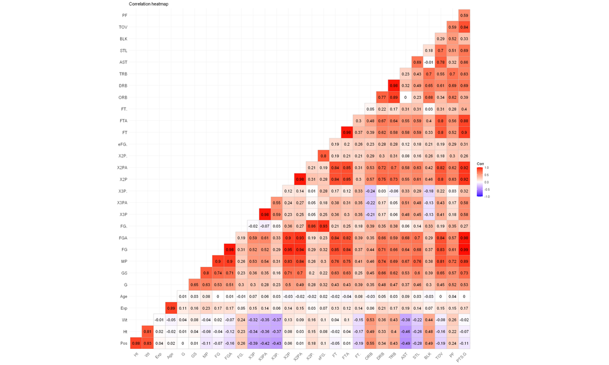

```r
cor_data = select(data, 2:31)

correlations <- cor(cor_data %>% type.convert(as.is=TRUE))
ggcorrplot(correlations, type = "lower", lab=TRUE, )
```

> Filter-based feature selection methods use statistical measures to score the correlation or dependence between input variables that can be filtered to choose the most relevant features.

*[Source](https://machinelearningmastery.com/feature-selection-with-real-and-categorical-data/)*

Let’s look at their distributions uni- and bi-variative. The differences among classes should be noticable.

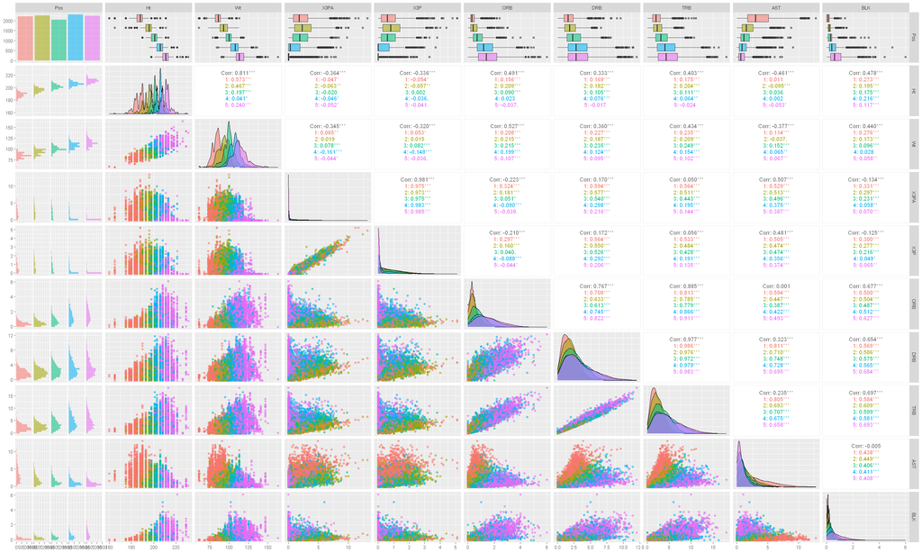

```r
attach(data)
ggpairs(select(data, Pos,Ht,Wt,X3PA,X3P,ORB,DRB,TRB,AST,BLK), aes(color=Pos, alpha=0.5))
```

Nice! Then I decided to use filter-based method called ANOVA in order to check their signifficance for the predictiing Pos.

```r
attach(data)
```

```r
anova <- aov(Pos~Ht*Wt*X3PA*X3P*ORB*DRB*TRB*AST*BLK)
smr <- summary(anova)


coef.tidy <- tidy(anova)
colnames(coef.tidy) <- c("Feature", "Df", "Sum_Sq", "Mean_Sq", "F_value", "pvalue")
coef.tidy[order(coef.tidy$F_value, decreasing = TRUE), ]
```

| Feature | Df | Sum_Sq | Mean_Sq | F_value | pvalue |
| --- | --- | --- | --- | --- | --- |
| Ht | 1 | 1.744096e+04 | 1.744096e+04 | 7.754500e+04 | 0.000000e+00 |
| Wt | 1 | 7.893640e+02 | 7.893640e+02 | 3.509624e+03 | 0.000000e+00 |
| AST | 1 | 2.065518e+02 | 2.065518e+02 | 9.183586e+02 | 1.655751e-193 |
| X3PA | 1 | 1.671119e+02 | 1.671119e+02 | 7.430030e+02 | 3.656772e-158 |
| ORB | 1 | 1.594045e+02 | 1.594045e+02 | 7.087350e+02 | 3.429533e-151 |
| Ht:ORB | 1 | 1.105264e+02 | 1.105264e+02 | 4.914161e+02 | 1.837527e-106 |
| Ht:X3PA | 1 | 9.374288e+01 | 9.374288e+01 | 4.167941e+02 | 6.827351e-91 |
| Ht:Wt:AST | 1 | 8.947397e+01 | 8.947397e+01 | 3.978139e+02 | 6.491744e-87 |
| Ht:Wt:X3PA | 1 | 8.614445e+01 | 8.614445e+01 | 3.830104e+02 | 8.321263e-84 |
| Ht:Wt | 1 | 7.468455e+01 | 7.468455e+01 | 3.320581e+02 | 4.485467e-73 |

[output cut: 502 more lines]

The table above shows all possible compinations of features and their impact on the target value. We assume the hypothesis that none of the features has impact on the target. The smaller p-value is, the bigger chances to reject this hypothesis and accept another one - some of the features have impact. The bigger F score is - the biger is impact.

Unfortunately, the first 5 (top) rows contain only one feature, it means ANOVA recommends to fit the model having only one feature…

Further I will try to fit first 9 combinations.